# Simulation Results UKB

Sahir

2018-05-30

This is a `knitr` report generated by the `simulator` to describe your simulation. Knitting this file will rerun the simulation if any of the code files have been modified since the `simulation` object was last created.

# Main simulation

## Simulation Details

To assess the performance of penfam we used genotyped data from the UK Biobank cohort to maintain LD structure. We restricted our simulation study to 1st degree relatives defined by the KING estimate for kinship coefficients resulting in $n=1069$ individuals. Note that not all of these individuals are related to eachother. This just means that each individual is related at least to 1 other person. We define the following quantities:

1. $c$: percentage of causal SNPs
2. $\mathbf{X}^{(test)}$: $n \times 1000$ matrix of SNPs that have been randomly sampled across the genome, with sampling weights proportional to the size of each chromosome. These are the SNPs that will be included as fixed effects in our model.
3. $\mathbf{X}^{(causal)}$: $n \times (c*1000)$ matrix of SNPs out of the SNPs included in the fixed effect model that will be truly associated with the simulated phenotype, where $\mathbf{X}^{(causal)} \subseteq \mathbf{X}^{(test)}$
4. $\mathbf{X}^{(other)}$: $n \times 8000$ matrix of SNPs that have been randomly sampled across the genome, with sampling weights proportional to the size of each chromosome. This matrix will be used in the construction of the kinship matrix ($\boldsymbol{\Phi}$). Some of these $\mathbf{X}^{(other)}$ SNPs, in conjunction with some of the SNPs in $\mathbf{X}^{(test)}$ will be used in construction of the kinship matrix. We will alter the balance between these two contributors and with the proportion of causal SNPs used to calculate kinship.
5. $\mathbf{X}^{(kinship)}$: $n \times k$ matrix of SNPs used to construct the kinship matrix.
6. $\beta_j$: effect size for the $j^{th}$ SNP, simulated from a $Uniform(0.9,1.1)$ for $j = 1, \ldots, (c*1000)$
7. The response is simulated as follows:

$$\mathbf{Y} | (\boldsymbol{\beta}, \eta, \sigma^2) \sim \mathcal{N}(\mu, \eta \sigma^2 \boldsymbol{\Phi} + (1-\eta)\sigma^2 \boldsymbol{I})$$

We will consider the following simulation scenarios. In each scenario we consider $c = 0.01$, $\eta=0.1, 0.5$ and $\sigma^2 = 4$ :

**Scenario 1**  
All the causal SNPs are included in the calculation of the kinship matrix.

$\mathbf{X}^{(kinship)} = \left[\mathbf{X}^{(other)} ; \mathbf{X}^{(causal)}\right]$

**Scenario 2**  
None of the causal SNPs are included in the calculation of the kinship matrix.

$\mathbf{X}^{(kinship)} = \left[\mathbf{X}^{(other)} \right]$

## Code used to produce results

```r
name_of_simulation <- "ssc-2018-penfam-v4"
# nsim needs to be at least 2

sim <- new_simulation(name_of_simulation, "SSC 2018", dir = "simulation/") %>%
  generate_model(make_mixed_model_SSC, b0 = 0, sigma2 = 4,
                 eta = 0.5,
                 percent_causal = 1,
                 percent_overlap = list("0","100"),
                 vary_along = "percent_overlap") %>%
  simulate_from_model(nsim = 4, index = 1:50) %>%
  run_method(list(lassoPCpf, PENFAM, TWOSTEP),
             parallel = list(socket_names = 35,
                             libraries = c("glmnet","magrittr","MASS","progress","Matrix","coxme","gaston")))

sim <- sim %>% evaluate(list(modelerror, tpr, fpr, nactive, eta, sigma2))
save_simulation(sim)

# we added an extra simulation scenario here.
sim <- simulator::load_simulation(name_of_simulation, dir = "simulation/")

mref <-  generate_model(make_model = make_mixed_model_SSC, b0 = 0, sigma2 = 4,
                        eta = 0.10,
                        percent_causal = 1,
                        percent_overlap = list("0","100"),
                        vary_along = "percent_overlap")

dref <- simulate_from_model(mref, nsim = 4, index = 1:50)
sim <- simulator::add(sim, mref)
sim <- simulator::add(sim, dref)
oref <- simulator::run_method(dref, list(lassoPCpf, PENFAM, TWOSTEP),
                              parallel = list(socket_names = 35,
                                              libraries = c("glmnet","magrittr","MASS","progress","Matrix","coxme","gaston")))
sim <- simulator::add(sim, oref)
simulator::save_simulation(sim)
sim
```

# Results

## Mean True Positive Rate (standard error) over 200 simulations

|  | Lasso with 10 PC Penalty Factor | Penfam | Two Step |
| --- | --- | --- | --- |
| percent_causal = 1, percent_overlap = 0, eta = 0.5, sigma = 4 | 1.000 (0.000) | 1.000 (0.000) | 1.000 (0.000) |
| percent_causal = 1, percent_overlap = 100, eta = 0.5, sigma = 4 | 1.000 (0.000) | 1.000 (0.000) | 1.000 (0.000) |
| percent_causal = 1, percent_overlap = 0, eta = 0.1, sigma = 4 | 1.000 (0.000) | 1.000 (0.000) | 1.000 (0.000) |
| percent_causal = 1, percent_overlap = 100, eta = 0.1, sigma = 4 | 1.000 (0.000) | 1.000 (0.000) | 1.000 (0.000) |

## Mean False Positive Rate (standard error) over 200 simulations

|  | Lasso with 10 PC Penalty Factor | Penfam | Two Step |
| --- | --- | --- | --- |
| percent_causal = 1, percent_overlap = 0, eta = 0.5, sigma = 4 | 0.078527 (0.0024178) | 0.003449 (0.0001863) | 0.013056 (0.0005123) |
| percent_causal = 1, percent_overlap = 100, eta = 0.5, sigma = 4 | 0.077997 (0.0025730) | 0.003606 (0.0001788) | 0.008980 (0.0003556) |
| percent_causal = 1, percent_overlap = 0, eta = 0.1, sigma = 4 | 0.051983 (0.0016120) | 0.003394 (0.0001916) | 0.012616 (0.0004480) |
| percent_causal = 1, percent_overlap = 100, eta = 0.1, sigma = 4 | 0.051942 (0.0015623) | 0.003520 (0.0001892) | 0.009187 (0.0003581) |

## Mean Number of Active Variables (standard error) over 200 simulations

Active variables: The number of variables with a non-zero estimated coefficient for a given model

|  | Lasso with 10 PC Penalty Factor | Penfam | Two Step |
| --- | --- | --- | --- |
| percent_causal = 1, percent_overlap = 0, eta = 0.5, sigma = 4 | 87.820 (2.396) | 13.415 (0.184) | 22.925 (0.507) |
| percent_causal = 1, percent_overlap = 100, eta = 0.5, sigma = 4 | 87.295 (2.550) | 13.570 (0.177) | 18.890 (0.352) |
| percent_causal = 1, percent_overlap = 0, eta = 0.1, sigma = 4 | 61.515 (1.598) | 13.360 (0.190) | 22.490 (0.444) |
| percent_causal = 1, percent_overlap = 100, eta = 0.1, sigma = 4 | 61.475 (1.548) | 13.485 (0.187) | 19.095 (0.355) |

## Mean Model Error (standard error) over 200 simulations

Model Error:
$$\Vert \mathbf{X}\beta - \mathbf{X}\hat\beta \Vert_2$$

|  | Lasso with 10 PC Penalty Factor | Penfam | Two Step |
| --- | --- | --- | --- |
| percent_causal = 1, percent_overlap = 0, eta = 0.5, sigma = 4 | 17.189 (0.162) | 19.975 (0.157) | 77.219 (0.246) |
| percent_causal = 1, percent_overlap = 100, eta = 0.5, sigma = 4 | 17.540 (0.158) | 21.212 (0.161) | 92.443 (0.195) |
| percent_causal = 1, percent_overlap = 0, eta = 0.1, sigma = 4 | 16.018 (0.130) | 19.908 (0.166) | 68.006 (0.304) |
| percent_causal = 1, percent_overlap = 100, eta = 0.1, sigma = 4 | 16.132 (0.127) | 20.149 (0.155) | 84.708 (0.213) |

## Estimation of variance components for ggmix only

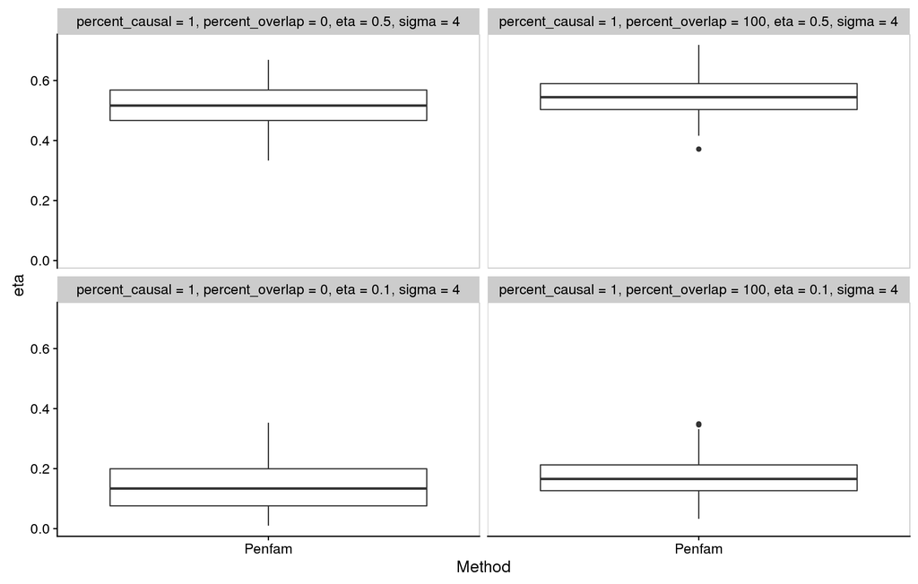

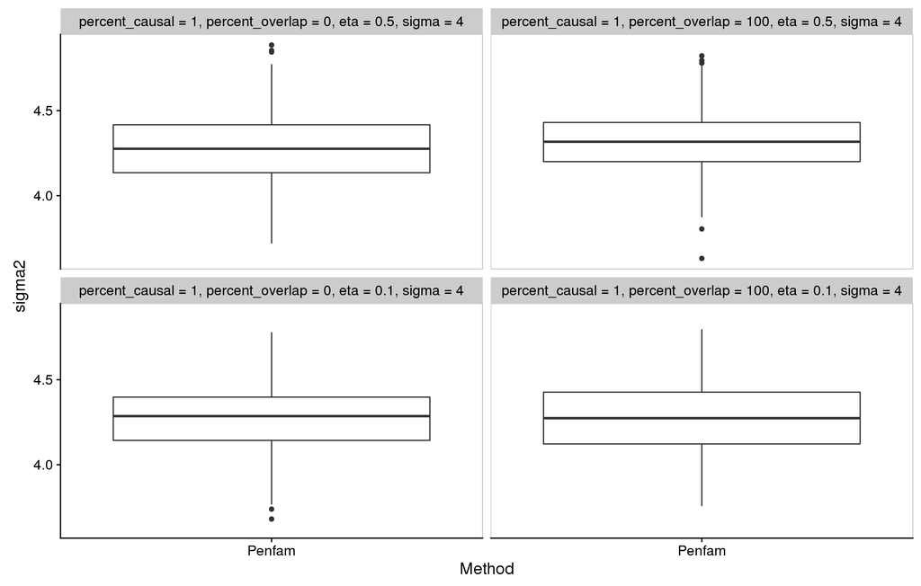

# Components

## Models

```r
make_mixed_model_SSC <- function(b0, eta, sigma2, percent_causal, percent_overlap) {

  if (percent_causal == 1) {

    file_paths <- switch(percent_overlap,
                         `0` = {
                           list(Phi = "/mnt/GREENWOOD_BACKUP/home/sahir.bhatnagar/penfam/simulation/data/kinship/Kinship_other_8k.rel",
                                Phi_names = "/mnt/GREENWOOD_BACKUP/home/sahir.bhatnagar/penfam/simulation/data/kinship/Kinship_other_8k.rel.id",
                                #X_phi is bed files used to make kinship
                                X_Phi = "/mnt/GREENWOOD_BACKUP/home/sahir.bhatnagar/penfam/simulation/data/bed/X_other_8k",
                                bedfile = "/mnt/GREENWOOD_BACKUP/home/sahir.bhatnagar/penfam/simulation/data/bed/X_test_1k",
                                causal_list = "/mnt/GREENWOOD_BACKUP/home/sahir.bhatnagar/penfam/simulation/data/snplist/causal_SNP_from_X_test_10")
                         },
                         `100` = {
                           list(Phi = "/mnt/GREENWOOD_BACKUP/home/sahir.bhatnagar/penfam/simulation/data/kinship/Kinship_other_7990_causal_10.rel",
                                Phi_names = "/mnt/GREENWOOD_BACKUP/home/sahir.bhatnagar/penfam/simulation/data/kinship/Kinship_other_7990_causal_10.rel.id",
                                #X_phi is bed files used to make kinship
                                X_Phi = "/mnt/GREENWOOD_BACKUP/home/sahir.bhatnagar/penfam/simulation/data/bed/X_other_7990_causal_10",
                                bedfile = "/mnt/GREENWOOD_BACKUP/home/sahir.bhatnagar/penfam/simulation/data/bed/X_test_1k",
                                causal_list = "/mnt/GREENWOOD_BACKUP/home/sahir.bhatnagar/penfam/simulation/data/snplist/causal_SNP_from_X_test_10")
                         })

  } else if (percent_causal == 2.5) {

    file_paths <- switch(percent_overlap,
                         `0` = {
                           list(Phi = "/mnt/GREENWOOD_BACKUP/home/sahir.bhatnagar/penfam/simulation/data/kinship/Kinship_other_4k.rel",
                                Phi_names = "/mnt/GREENWOOD_BACKUP/home/sahir.bhatnagar/penfam/simulation/data/kinship/Kinship_other_4k.rel.id",
                                #X_phi is bed files used to make kinship
                                X_Phi = "/mnt/GREENWOOD_BACKUP/home/sahir.bhatnagar/penfam/simulation/data/bed/X_other_4k",
                                bedfile = "/mnt/GREENWOOD_BACKUP/home/sahir.bhatnagar/penfam/simulation/data/bed/X_test_4k",
                                causal_list = "/mnt/GREENWOOD_BACKUP/home/sahir.bhatnagar/penfam/simulation/data/snplist/causal_SNP_from_X_test_100")
                         },
                         `100` = {
                           list(Phi = "/mnt/GREENWOOD_BACKUP/home/sahir.bhatnagar/penfam/simulation/data/kinship/Kinship_other_7900_causal_100.rel",
                                Phi_names = "/mnt/GREENWOOD_BACKUP/home/sahir.bhatnagar/penfam/simulation/data/kinship/Kinship_other_7900_causal_100.rel.id",
                                #X_phi is bed files used to make kinship
                                X_Phi = "/mnt/GREENWOOD_BACKUP/home/sahir.bhatnagar/penfam/simulation/data/bed/X_other_7900_causal_100",
                                bedfile = "/mnt/GREENWOOD_BACKUP/home/sahir.bhatnagar/penfam/simulation/data/bed/X_test_4k",
                                causal_list = "/mnt/GREENWOOD_BACKUP/home/sahir.bhatnagar/penfam/simulation/data/snplist/causal_SNP_from_X_test_100")
                         })

  } else if (percent_causal == 10) {

    file_paths <- switch(percent_overlap,
                         `0` = {
                           list(Phi = "/mnt/GREENWOOD_BACKUP/home/sahir.bhatnagar/penfam/simulation/data/kinship/Kinship_other_4k.rel",
                                Phi_names = "/mnt/GREENWOOD_BACKUP/home/sahir.bhatnagar/penfam/simulation/data/kinship/Kinship_other_4k.rel.id",
                                bedfile = "/mnt/GREENWOOD_BACKUP/home/sahir.bhatnagar/penfam/simulation/data/bed/X_test_4k",
                                causal_list = "/mnt/GREENWOOD_BACKUP/home/sahir.bhatnagar/penfam/simulation/data/snplist/causal_SNP_from_X_test_400")
                         },
                         `50` = {
                           list(Phi = "/mnt/GREENWOOD_BACKUP/home/sahir.bhatnagar/penfam/simulation/data/kinship/Kinship_other_3800_causal_200.rel",
                                Phi_names = "/mnt/GREENWOOD_BACKUP/home/sahir.bhatnagar/penfam/simulation/data/kinship/Kinship_other_3800_causal_200.rel.id",
                                bedfile = "/mnt/GREENWOOD_BACKUP/home/sahir.bhatnagar/penfam/simulation/data/bed/X_test_4k",
                                causal_list = "/mnt/GREENWOOD_BACKUP/home/sahir.bhatnagar/penfam/simulation/data/snplist/causal_SNP_from_X_test_400")
                         },
                         `100` = {
                           list(Phi = "/mnt/GREENWOOD_BACKUP/home/sahir.bhatnagar/penfam/simulation/data/kinship/Kinship_other_3600_causal_400.rel",
                                Phi_names = "/mnt/GREENWOOD_BACKUP/home/sahir.bhatnagar/penfam/simulation/data/kinship/Kinship_other_3600_causal_400.rel.id",
                                bedfile = "/mnt/GREENWOOD_BACKUP/home/sahir.bhatnagar/penfam/simulation/data/bed/X_test_4k",
                                causal_list = "/mnt/GREENWOOD_BACKUP/home/sahir.bhatnagar/penfam/simulation/data/snplist/causal_SNP_from_X_test_400")
                         })

  } else if (percent_causal == 50) {

    file_paths <- switch(percent_overlap,
                         `0` = {
                           list(Phi = "/mnt/GREENWOOD_BACKUP/home/sahir.bhatnagar/penfam/simulation/data/kinship/Kinship_other_4k.rel",
                                Phi_names = "/mnt/GREENWOOD_BACKUP/home/sahir.bhatnagar/penfam/simulation/data/kinship/Kinship_other_4k.rel.id",
                                bedfile = "/mnt/GREENWOOD_BACKUP/home/sahir.bhatnagar/penfam/simulation/data/bed/X_test_4k",
                                causal_list = "/mnt/GREENWOOD_BACKUP/home/sahir.bhatnagar/penfam/simulation/data/snplist/causal_SNP_from_X_test_2000")
                         },
                         `50` = {
                           list(Phi = "/mnt/GREENWOOD_BACKUP/home/sahir.bhatnagar/penfam/simulation/data/kinship/Kinship_other_3000_causal_1000.rel",
                                Phi_names = "/mnt/GREENWOOD_BACKUP/home/sahir.bhatnagar/penfam/simulation/data/kinship/Kinship_other_3000_causal_1000.rel.id",
                                bedfile = "/mnt/GREENWOOD_BACKUP/home/sahir.bhatnagar/penfam/simulation/data/bed/X_test_4k",
                                causal_list = "/mnt/GREENWOOD_BACKUP/home/sahir.bhatnagar/penfam/simulation/data/snplist/causal_SNP_from_X_test_2000")
                         },
                         `100` = {
                           list(Phi = "/mnt/GREENWOOD_BACKUP/home/sahir.bhatnagar/penfam/simulation/data/kinship/Kinship_other_2000_causal_2000.rel",
                                Phi_names = "/mnt/GREENWOOD_BACKUP/home/sahir.bhatnagar/penfam/simulation/data/kinship/Kinship_other_2000_causal_2000.rel.id",
                                bedfile = "/mnt/GREENWOOD_BACKUP/home/sahir.bhatnagar/penfam/simulation/data/bed/X_test_4k",
                                causal_list = "/mnt/GREENWOOD_BACKUP/home/sahir.bhatnagar/penfam/simulation/data/snplist/causal_SNP_from_X_test_2000")
                         })
  }

  # gaston kinship
  Phi <- gaston::read.bed.matrix(file_paths$X_Phi)
  kin <- gaston::GRM(Phi, autosome.only = FALSE)
  kin[1:5,1:5]
  all(complete.cases(kin))
  eiK <- eigen(kin)
  # all(rownames(as.matrix(x))==rownames(kin))
  # deal with a small negative eigen value
  any(eiK$values < 0)
  eiK$values[ eiK$values < 0 ] <- 0
  PC <- sweep(eiK$vectors, 2, sqrt(eiK$values), "*")

  dat <- gaston::read.bed.matrix(file_paths$bedfile)
  gaston::standardize(dat) <- "p"
  X <- as.matrix(dat)
  any(is.na(X))
  X[is.na(X)] <- 0
  any(is.na(X))
  X[1:5,1:5]

  # need to re-order
  all(rownames(X)==rownames(kin))
  all(rownames(X) %in% rownames(kin))
  X <- X[match(rownames(kin), rownames(X)),]
  all(rownames(X)==rownames(kin))

  np <- dim(X)
  n <- np[[1]]
  p <- np[[2]]

  all(rownames(X)==rownames(kin))

  x_lasso <- cbind(X,PC[,1:10])
  x_lasso[1:5,1:5]

  causal <- data.table::fread(file_paths$causal_list, header = FALSE)$V1
  not_causal <- setdiff(colnames(X), causal)
  beta <- rep(0, length = p)
  beta[which(colnames(X) %in% causal)] <- runif(n = length(causal), 0.9, 1.1)
  mu <- as.numeric(X %*% beta)

  new_model(name = "ggmixSSCv2", label = sprintf("percent_causal = %s, percent_overlap = %s, eta = %s, sigma = %s",
                                                 percent_causal, percent_overlap, eta, sigma2),
            params = list(mu = mu, n = n, x = X, x_lasso = x_lasso,
                          beta = beta, percent_causal = percent_causal,
                          percent_overlap = percent_overlap,
                          not_causal = not_causal,
                          kin = kin, b0 = b0, sigma2 = sigma2, eta = eta, causal = causal),
            simulate = function(mu, sigma2, eta, kin, n, nsim) {
              P <- MASS::mvrnorm(nsim, mu = rep(0, n), Sigma = eta * sigma2 * kin)
              E <- MASS::mvrnorm(nsim, mu = rep(0, n), Sigma = (1 - eta) * sigma2 * diag(n))
              y <- b0 + mu + t(P) + t(E)
              return(split(y, col(y))) # make each col its own list element
            })
}
```

## Methods

```r
source("/mnt/GREENWOOD_BACKUP/home/sahir.bhatnagar/ggmix/simulation/packages.R")
source("/mnt/GREENWOOD_BACKUP/home/sahir.bhatnagar/ggmix/simulation/functions.R")

lasso <- new_method("lasso", "Lasso",
                    method = function(model, draw) {
                      fitglmnet <- cv.glmnet(x = model$x, y = draw, alpha = 1, standardize = F)
                      list(beta = coef(fitglmnet, s = "lambda.min")[-1,,drop=F],
                           yhat = predict(fitglmnet, newx = model$x, s = "lambda.min"),
                           nonzero = coef(fitglmnet)[nonzeroCoef(coef(fitglmnet)),,drop=F],
                           nonzero_names = setdiff(rownames(coef(fitglmnet)[nonzeroCoef(coef(fitglmnet)),,drop=F]),c("(Intercept)")),
                           y = draw)
                    })

lassoPCpf <- new_method("lassoPCpf", "Lasso with 10 PC Penalty Factor",
                      method = function(model, draw) {
                        fitglmnet <- cv.glmnet(x = model$x_lasso, y = draw, alpha = 1, standardize = T,
                                               penalty.factor = c(rep(1, ncol(model$x)), rep(0,10)))

                        model_error <- l2norm(model$mu -
                                              model$x %*% coef(fitglmnet, s = "lambda.min")[2:(ncol(model$x)+1),,drop=F])

                        list(beta = coef(fitglmnet, s = "lambda.min")[-1,,drop=F],
                             model_error = model_error,
                             eta = NA,
                             sigma2 = NA,
                             yhat = predict(fitglmnet, newx = model$x_lasso, s = "lambda.min"),
                             nonzero = coef(fitglmnet, s = "lambda.min")[nonzeroCoef(coef(fitglmnet, s = "lambda.min")),,drop=F],
                             nonzero_names = setdiff(rownames(coef(fitglmnet, s = "lambda.min")[nonzeroCoef(coef(fitglmnet, s = "lambda.min")),,drop=F]),c("(Intercept)")),
                             y = draw)
                      })

PENFAM <- new_method("penfam", "Penfam",
                     method = function(model, draw) {
                       fit <- penfam(x = model$x,
                                     y = draw,
                                     phi = model$kin,
                                     thresh_glmnet = 1e-10,
                                     epsilon = 1e-5,
                                     fdev = 1e-7,
                                     alpha = 1,
                                     tol.kkt = 1e-3,
                                     nlambda = 100,
                                     # an = log(log(model$n)) * log(model$n),
                                     # an = log(log(1000)),
                                     an = log(length(draw)),
                                     # lambda_min_ratio  = ifelse(model$n < model$p, 0.01, 0.001),
                                     lambda_min_ratio  = 0.05,
                                     eta_init = 0.5,
                                     maxit = 100)

                       model_error <- l2norm(model$mu -
                                               model$x %*% coef(fit, s = fit$lambda_min)[2:(ncol(model$x)+1),,drop=F])

                       list(beta = fit$beta[,fit$lambda_min,drop=F], #this doesnt have intercept and is a 1-col matrix
                            model_error = model_error,
                            nonzero = predict(fit, type = "nonzero", s = fit$lambda_min),
                            nonzero_names = setdiff(rownames(predict(fit, type = "nonzero", s = fit$lambda_min)), c("(Intercept)","eta","sigma2")),
                            yhat = fit$predicted[,fit$lambda_min],
                            eta = fit$eta[,fit$lambda_min],
                            sigma2 = fit$sigma2[,fit$lambda_min],
                            y = draw
                       )
                     })



TWOSTEP <- new_method("twostep", "Two Step",
                      method = function(model, draw) {

                        # pheno_dat <- data.frame(Y = draw, id = rownames(model$kin))
                        # fit_lme <- coxme::lmekin(Y ~ 1 + (1|id), data = pheno_dat, varlist = model$kin)
                        # newy <- residuals(fit_lme)
                        # fitglmnet <- glmnet::cv.glmnet(x = model$x, y = newy, standardize = F, alpha = 1)

                        # pheno_dat <- data.frame(Y = draw, id = rownames(model$kin))
                        x1 <- cbind(rep(1, nrow(model$x)))
                        fit_lme <- gaston::lmm.aireml(draw, x1, K = model$kin)
                        gaston_resid <- draw - (fit_lme$BLUP_omega + fit_lme$BLUP_beta)
                        fitglmnet <- glmnet::cv.glmnet(x = model$x, y = gaston_resid,
                                                       standardize = T, alpha = 1, intercept = T)

                        model_error <- l2norm(model$mu -
                                                model$x %*% coef(fitglmnet, s = "lambda.min")[2:(ncol(model$x)+1),,drop=F])

                        list(beta = coef(fitglmnet, s = "lambda.min")[-1,,drop=F],
                             yhat = predict(fitglmnet, newx = model$x, s = "lambda.min"),
                             nonzero = coef(fitglmnet, s = "lambda.min")[nonzeroCoef(coef(fitglmnet, s = "lambda.min")),,drop=F],
                             nonzero_names = setdiff(rownames(coef(fitglmnet, s = "lambda.min")[nonzeroCoef(coef(fitglmnet, s = "lambda.min")),,drop=F]),c("(Intercept)")),
                             model_error = model_error,
                             eta = NA,
                             sigma2 = NA,
                             y = draw)
                      })
```

## Metrics

```r
eta <- new_metric("eta", "eta",
                  metric = function(model, out) out$eta)

sigma2 <- new_metric("sigma2", "sigma2",
                     metric = function(model, out) out$sigma2)

modelerror <- new_metric("me", "model error",
                     metric = function(model, out) out$model_error)

tpr <- new_metric("tpr", "True Positive Rate",
                  metric = function(model, out) {
                    length(intersect(out$nonzero_names, model$causal))/length(model$causal)
                  })

"%ni%" <- Negate("%in%")

fpr <- new_metric("fpr", "False Positive Rate",
                  metric = function(model, out){
                    # these are the terms which the model identified as zero
                    modelIdentifyZero <- setdiff(colnames(model$x), out$nonzero_names)
                    FPR <- sum(out$nonzero_names %ni% model$causal) / (sum(out$nonzero_names %ni% model$causal) + sum(modelIdentifyZero %in% model$not_causal))
                    FPR
                  })

nactive <- new_metric("nactive", "Number of Active Variables",
                      metric = function(model, out) {
                        length(out$nonzero_names)
                      })
```

# References

```r
citation(c("simulator"))
```

Bien J (2016). “The simulator: An Engine to Streamline Simulations.” *Submitted*. <URL: http://faculty.bscb.cornell.edu/~bien/simulator.pdf>.

A BibTeX entry for LaTeX users is

@Article{, title = {The {simulator}: An Engine to Streamline Simulations}, author = {Jacob Bien}, year = {2016}, url = {http://faculty.bscb.cornell.edu/~bien/simulator.pdf}, journal = {Submitted}, }

```r
citation(c("glmnet"))
```

To cite glmnet in publications use:

Jerome Friedman, Trevor Hastie, Robert Tibshirani (2010). Regularization Paths for Generalized Linear Models via Coordinate Descent. Journal of Statistical Software, 33(1), 1-22. URL http://www.jstatsoft.org/v33/i01/.

If coxnet is used, please also cite:

Noah Simon, Jerome Friedman, Trevor Hastie, Rob Tibshirani (2011). Regularization Paths for Cox’s Proportional Hazards Model via Coordinate Descent. Journal of Statistical Software, 39(5), 1-13. URL http://www.jstatsoft.org/v39/i05/.

To see these entries in BibTeX format, use ‘print(, bibtex=TRUE)’, ‘toBibtex(.)’, or set ‘options(citation.bibtex.max=999)’.

```r
citation(c("gaston"))
```

To cite package ‘gaston’ in publications use:

Claire Dandine-Roulland (2018). gaston: Genetic Data Handling (QC, GRM, LD, PCA) & Linear Mixed Models. R package version 1.5.3. https://CRAN.R-project.org/package=gaston

A BibTeX entry for LaTeX users is

@Manual{, title = {gaston: Genetic Data Handling (QC, GRM, LD, PCA) & Linear Mixed Models}, author = {Claire Dandine-Roulland}, year = {2018}, note = {R package version 1.5.3}, url = {https://CRAN.R-project.org/package=gaston}, }

```r
citation(c("magrittr"))
```

To cite package ‘magrittr’ in publications use:

Stefan Milton Bache and Hadley Wickham (2014). magrittr: A Forward-Pipe Operator for R. R package version 1.5. https://CRAN.R-project.org/package=magrittr

A BibTeX entry for LaTeX users is

@Manual{, title = {magrittr: A Forward-Pipe Operator for R}, author = {Stefan Milton Bache and Hadley Wickham}, year = {2014}, note = {R package version 1.5}, url = {https://CRAN.R-project.org/package=magrittr}, }

ATTENTION: This citation information has been auto-generated from the package DESCRIPTION file and may need manual editing, see ‘help(“citation”)’.

```r
citation(c("ggplot2"))
```

To cite ggplot2 in publications, please use:

H. Wickham. ggplot2: Elegant Graphics for Data Analysis. Springer-Verlag New York, 2009.

A BibTeX entry for LaTeX users is

@Book{, author = {Hadley Wickham}, title = {ggplot2: Elegant Graphics for Data Analysis}, publisher = {Springer-Verlag New York}, year = {2009}, isbn = {978-0-387-98140-6}, url = {http://ggplot2.org}, }

```r
citation(c("knitr"))
```

To cite the ‘knitr’ package in publications use:

Yihui Xie (2018). knitr: A General-Purpose Package for Dynamic Report Generation in R. R package version 1.20.

Yihui Xie (2015) Dynamic Documents with R and knitr. 2nd edition. Chapman and Hall/CRC. ISBN 978-1498716963

Yihui Xie (2014) knitr: A Comprehensive Tool for Reproducible Research in R. In Victoria Stodden, Friedrich Leisch and Roger D. Peng, editors, Implementing Reproducible Computational Research. Chapman and Hall/CRC. ISBN 978-1466561595

To see these entries in BibTeX format, use ‘print(, bibtex=TRUE)’, ‘toBibtex(.)’, or set ‘options(citation.bibtex.max=999)’.